# Machine Learning

```r
library(readr)
library(caTools)
library(ROCR)
library(rpart)
library(rpart.plot)
library(randomForest)
dcc <- read_csv("~/dcc.csv")
```

The data set needs to be transformed into a data frame.

## Data Analysis

In this section we will use machine learning methods to build three different models that will predict the probability of either a default or no default using the independent variables in our data set. We will build a logistic regression model, a classification and regression tree (CART), and a random forest model.

We saw earlier that the default rate across all loans is 22.12%, which means that 77.88% of loans are not defaulting. Our goal is to improve upon the baseline with each model.

### Logistic Regression

We first split the data into a training data set and testing data set. We will use the training set to discover potentially predictive relationships and use the testing set to assess the performance of these relationships.

Our training set uses 75% of the observations, and our testing set uses 25%. The set.seed variable is used to make sure the dependent variable (default) is well balanced in both the training and testing sets.

```r
# Split data into training and testing set with a 75/25 ratio
set.seed(64)
split = sample.split(dcc$DefaultOct05, SplitRatio = 0.75)
dccTrain = subset(dcc, split == TRUE)
dccTest = subset(dcc, split == FALSE)
```

```r
# Check rows for both the training and testing set
nrow(dccTrain)
```

```
## [1] 22500
```

```r
nrow(dccTest)
```

```
## [1] 7500
```

We see there are 22,500 rows in the training data set and 7,500 in the testing data set which is consistent with a 75/25 split.

We will now build our model using the training data set. We start with a large universe of variables and continue to refine our model by removing those with no significance.

##### Model1

```r
# Model 1 starts with almost all the independent variables
dccLog1 = glm(DefaultOct05 ~ LimitAmt + Gender + Education + Marriage + Age +
                StatusSep05 + StatusAug05 + StatusJul05 + StatusJun05 + StatusMay05 +
                StatusApr05 + PayAmtSep05 + PayAmtAug05 + PayAmtMay05 + PayAmtApr05 +
                BalSep05 + BalAug05 + BalJul05 + BalJun05 + BalMay05 + BalApr05,
              data=dccTrain, family=binomial)

summary(dccLog1)
```

```
##
## Call:
## glm(formula = DefaultOct05 ~ LimitAmt + Gender + Education +
##     Marriage + Age + StatusSep05 + StatusAug05 + StatusJul05 +
##     StatusJun05 + StatusMay05 + StatusApr05 + PayAmtSep05 + PayAmtAug05 +
##     PayAmtMay05 + PayAmtApr05 + BalSep05 + BalAug05 + BalJul05 +
##     BalJun05 + BalMay05 + BalApr05, family = binomial, data = dccTrain)
##
## Deviance Residuals:
##     Min       1Q   Median       3Q      Max
## -3.1067  -0.6993  -0.5482  -0.2893   3.5383
##
## Coefficients:
##               Estimate Std. Error z value Pr(>|z|)
## (Intercept) -8.687e-01  1.370e-01  -6.342 2.27e-10 ***
## LimitAmt    -6.821e-07  1.804e-07  -3.781 0.000156 ***
## Gender      -1.108e-01  3.540e-02  -3.129 0.001752 **
## Education   -1.647e-02  2.566e-02  -0.642 0.520960
## Marriage    -1.446e-01  3.644e-02  -3.969 7.22e-05 ***
## Age          6.969e-03  2.048e-03   3.403 0.000666 ***
## StatusSep05  5.740e-01  2.044e-02  28.078  < 2e-16 ***
## StatusAug05  9.571e-02  2.331e-02   4.105 4.04e-05 ***
## StatusJul05  7.012e-02  2.611e-02   2.686 0.007235 **
## StatusJun05  1.385e-02  2.885e-02   0.480 0.631193
## StatusMay05  3.701e-02  3.095e-02   1.196 0.231738
## StatusApr05  1.471e-02  2.561e-02   0.574 0.565730
## PayAmtSep05 -1.811e-05  2.971e-06  -6.096 1.09e-09 ***
## PayAmtAug05 -7.498e-06  2.249e-06  -3.335 0.000854 ***
## PayAmtMay05 -7.128e-06  2.216e-06  -3.216 0.001299 **
## PayAmtApr05 -2.125e-06  1.505e-06  -1.413 0.157788
## BalSep05    -6.055e-06  1.304e-06  -4.642 3.45e-06 ***
## BalAug05     4.127e-06  1.703e-06   2.423 0.015387 *
## BalJul05     7.717e-07  1.353e-06   0.570 0.568505
## BalJun05     8.548e-07  1.214e-06   0.704 0.481495
## BalMay05    -2.965e-06  1.644e-06  -1.803 0.071374 .
## BalApr05     2.420e-06  1.441e-06   1.679 0.093164 .
## ---
## Signif. codes:  0 '***' 0.001 '**' 0.01 '*' 0.05 '.' 0.1 ' ' 1
##
## (Dispersion parameter for binomial family taken to be 1)
##
##     Null deviance: 23779  on 22499  degrees of freedom
## Residual deviance: 20891  on 22478  degrees of freedom
## AIC: 20935
##
## Number of Fisher Scoring iterations: 6
```

We see that 7 variables are not significant. We will remove the variables with no significance and rerun the model.

##### Model2

```r
# Model 2 removes insignificant variables
dccLog2 = glm(DefaultOct05 ~ LimitAmt + Gender + Marriage + Age +
                StatusSep05 + StatusAug05 + StatusJul05 + PayAmtSep05 + PayAmtAug05 +
                PayAmtMay05 + BalSep05 + BalAug05 + BalMay05 + BalApr05,
              data=dccTrain, family=binomial)

summary(dccLog2)
```

```
##
## Call:
## glm(formula = DefaultOct05 ~ LimitAmt + Gender + Marriage + Age +
##     StatusSep05 + StatusAug05 + StatusJul05 + PayAmtSep05 + PayAmtAug05 +
##     PayAmtMay05 + BalSep05 + BalAug05 + BalMay05 + BalApr05,
##     family = binomial, data = dccTrain)
##
## Deviance Residuals:
##     Min       1Q   Median       3Q      Max
## -3.1097  -0.6972  -0.5480  -0.2919   3.5601
##
## Coefficients:
##               Estimate Std. Error z value Pr(>|z|)
## (Intercept) -9.028e-01  1.298e-01  -6.954 3.54e-12 ***
## LimitAmt    -7.490e-07  1.725e-07  -4.343 1.40e-05 ***
## Gender      -1.116e-01  3.535e-02  -3.156 0.001598 **
## Marriage    -1.426e-01  3.622e-02  -3.936 8.30e-05 ***
## Age          6.731e-03  2.012e-03   3.344 0.000825 ***
## StatusSep05  5.799e-01  2.029e-02  28.577  < 2e-16 ***
## StatusAug05  1.015e-01  2.305e-02   4.405 1.06e-05 ***
## StatusJul05  1.021e-01  2.154e-02   4.743 2.11e-06 ***
## PayAmtSep05 -1.867e-05  2.970e-06  -6.287 3.24e-10 ***
## PayAmtAug05 -6.270e-06  1.989e-06  -3.152 0.001621 **
## PayAmtMay05 -7.891e-06  2.196e-06  -3.594 0.000326 ***
## BalSep05    -6.296e-06  1.301e-06  -4.839 1.30e-06 ***
## BalAug05     4.934e-06  1.441e-06   3.425 0.000614 ***
## BalMay05    -2.397e-06  1.467e-06  -1.634 0.102188
## BalApr05     3.054e-06  1.403e-06   2.176 0.029539 *
## ---
## Signif. codes:  0 '***' 0.001 '**' 0.01 '*' 0.05 '.' 0.1 ' ' 1
##
## (Dispersion parameter for binomial family taken to be 1)
##
##     Null deviance: 23779  on 22499  degrees of freedom
## Residual deviance: 20903  on 22485  degrees of freedom
## AIC: 20933
##
## Number of Fisher Scoring iterations: 6
```

We see an improvement in the AIC score from 20935 to 20933, but one of the remaining variables is not significant. Once again, we will remove this variable and rerun the model.

##### Model3

```r
# Model 3 removes one more that is insignificant
dccLog3 = glm(DefaultOct05 ~ LimitAmt + Gender + Marriage + Age +
                StatusSep05 + StatusAug05 + StatusJul05 + PayAmtSep05 + PayAmtAug05 +
                PayAmtMay05 + BalSep05 + BalAug05 + BalApr05,
              data=dccTrain, family=binomial)

summary(dccLog3)
```

```
##
## Call:
## glm(formula = DefaultOct05 ~ LimitAmt + Gender + Marriage + Age +
##     StatusSep05 + StatusAug05 + StatusJul05 + PayAmtSep05 + PayAmtAug05 +
##     PayAmtMay05 + BalSep05 + BalAug05 + BalApr05, family = binomial,
##     data = dccTrain)
##
## Deviance Residuals:
##     Min       1Q   Median       3Q      Max
## -3.1082  -0.6969  -0.5477  -0.2931   3.6157
##
## Coefficients:
##               Estimate Std. Error z value Pr(>|z|)
## (Intercept) -9.031e-01  1.298e-01  -6.957 3.47e-12 ***
## LimitAmt    -7.727e-07  1.719e-07  -4.495 6.97e-06 ***
## Gender      -1.119e-01  3.534e-02  -3.165 0.001549 **
## Marriage    -1.426e-01  3.623e-02  -3.936 8.30e-05 ***
## Age          6.772e-03  2.012e-03   3.365 0.000764 ***
## StatusSep05  5.798e-01  2.029e-02  28.571  < 2e-16 ***
## StatusAug05  1.012e-01  2.305e-02   4.392 1.12e-05 ***
## StatusJul05  1.017e-01  2.153e-02   4.723 2.33e-06 ***
## PayAmtSep05 -1.888e-05  2.974e-06  -6.348 2.18e-10 ***
## PayAmtAug05 -6.723e-06  1.973e-06  -3.406 0.000658 ***
## PayAmtMay05 -6.319e-06  1.970e-06  -3.207 0.001340 **
## BalSep05    -6.385e-06  1.303e-06  -4.900 9.57e-07 ***
## BalAug05     4.659e-06  1.434e-06   3.249 0.001156 **
## BalApr05     1.036e-06  6.431e-07   1.610 0.107379
## ---
## Signif. codes:  0 '***' 0.001 '**' 0.01 '*' 0.05 '.' 0.1 ' ' 1
##
## (Dispersion parameter for binomial family taken to be 1)
##
##     Null deviance: 23779  on 22499  degrees of freedom
## Residual deviance: 20906  on 22486  degrees of freedom
## AIC: 20934
##
## Number of Fisher Scoring iterations: 6
```

The April Balance amount is insignificant. After removing this variable we run our model once more, however the AIC score is slightly higher (moving from 20933 to 20934)

##### Model4

```r
# Model 4 shows all remaining variables with significance
dccLog4 = glm(DefaultOct05 ~ LimitAmt + Gender + Marriage + Age +
                StatusSep05 + StatusAug05 + StatusJul05 + PayAmtSep05 + PayAmtAug05 +
                PayAmtMay05 + BalSep05 + BalAug05,
              data=dccTrain, family=binomial)

summary(dccLog4)
```

```
##
## Call:
## glm(formula = DefaultOct05 ~ LimitAmt + Gender + Marriage + Age +
##     StatusSep05 + StatusAug05 + StatusJul05 + PayAmtSep05 + PayAmtAug05 +
##     PayAmtMay05 + BalSep05 + BalAug05, family = binomial, data = dccTrain)
##
## Deviance Residuals:
##     Min       1Q   Median       3Q      Max
## -3.1156  -0.6971  -0.5483  -0.2933   3.6443
##
## Coefficients:
##               Estimate Std. Error z value Pr(>|z|)
## (Intercept) -9.058e-01  1.298e-01  -6.979 2.97e-12 ***
## LimitAmt    -7.458e-07  1.709e-07  -4.364 1.28e-05 ***
## Gender      -1.102e-01  3.533e-02  -3.120 0.001811 **
## Marriage    -1.431e-01  3.622e-02  -3.952 7.75e-05 ***
## Age          6.754e-03  2.012e-03   3.357 0.000788 ***
## StatusSep05  5.813e-01  2.027e-02  28.673  < 2e-16 ***
## StatusAug05  1.014e-01  2.304e-02   4.400 1.08e-05 ***
## StatusJul05  1.042e-01  2.148e-02   4.850 1.23e-06 ***
## PayAmtSep05 -1.926e-05  2.966e-06  -6.494 8.34e-11 ***
## PayAmtAug05 -6.315e-06  1.950e-06  -3.238 0.001202 **
## PayAmtMay05 -5.568e-06  1.901e-06  -2.930 0.003394 **
## BalSep05    -6.420e-06  1.297e-06  -4.949 7.46e-07 ***
## BalAug05     5.395e-06  1.352e-06   3.991 6.57e-05 ***
## ---
## Signif. codes:  0 '***' 0.001 '**' 0.01 '*' 0.05 '.' 0.1 ' ' 1
##
## (Dispersion parameter for binomial family taken to be 1)
##
##     Null deviance: 23779  on 22499  degrees of freedom
## Residual deviance: 20908  on 22487  degrees of freedom
## AIC: 20934
##
## Number of Fisher Scoring iterations: 6
```

Model 4 appears to be the best mix of independent variables as it delivers an AIC score of 20934, and shows significance of between 0 and 0.001 or between 0.001 and 0.01 for all independent variables. The coefficients for Age, payment status, and the August balance variable are positive, which indicates that higher values are indicative of a higher chance of default.

#### Predict the data

By using a threshold value, we can convert our probabilities to predictions. If the probability of default is greater than the threshold, then we predict default. If its below, then we predict no default. The threshold we start with is based on what type of error we are more comfortable with. A high threshold will lead to fewer innacurately predicted defaults but more innacurate predictions of a loan non defaulting. A low threshold will lead to the opposite. If there is no preference between the two errors we can choose a threshold of 0.5 since it is in between our two outcomes (0 or 1).

Using a threshold of 0.5, lets look at how our model works with the test data set.

```r
# Prediction on Test data
predictdccTest = predict(dccLog4, type="response", newdata = dccTest)
table(dccTest$DefaultOct05, predictdccTest > 0.5)
```

```
##
##     FALSE TRUE
##   0  5682  159
##   1  1251  408
```

The matrix above shows the breakdown of of all defaults. The rows are the acutal result (0 = no default, 1 = default), the columns are the predictions. We see that out of 7,500 occurrences, we have 6090 correct predictions (5682 loans predicted to be paid off, 408 predicted to default).

However, 1251 loans did default that were predicted to be paid off. We also see that of the loans predicted to default, 159 were actually paid off.

Our overall accuracy measures the number of correct predictions divided by the total number of loans.

```r
# Check for accuracy of model
TestAccuracy = (5682 + 408)/(5682 + 408 + 1251 + 159)
TestAccuracy
```

```
## [1] 0.812
```

The accuracy of the model is 81.2%.

This tells us that our model is a better predictor of default compared to a random guess, or our baseline (77.88%).

### Classification Tree

While logistic regression shows how an independent variable may be predictive for a specific outcome, it’s difficult to understand which factors are most important, and to evaluate what the prediction is for a new case.

The classification tree also predicts the probability of a specific outcome. By following a split in the tree, we can predict the most frequent outcome in the training set that followed the same path.

We use the same training and testing as with our logistic regression model.

```r
# Split data and create train/test sets
set.seed(64)
split = sample.split(dcc$DefaultOct05, SplitRatio = 0.75)
dccTrain = subset(dcc, split == TRUE)
dccTest = subset(dcc, split == FALSE)
```

We then build the model, and examine the tree. and its accuracy.

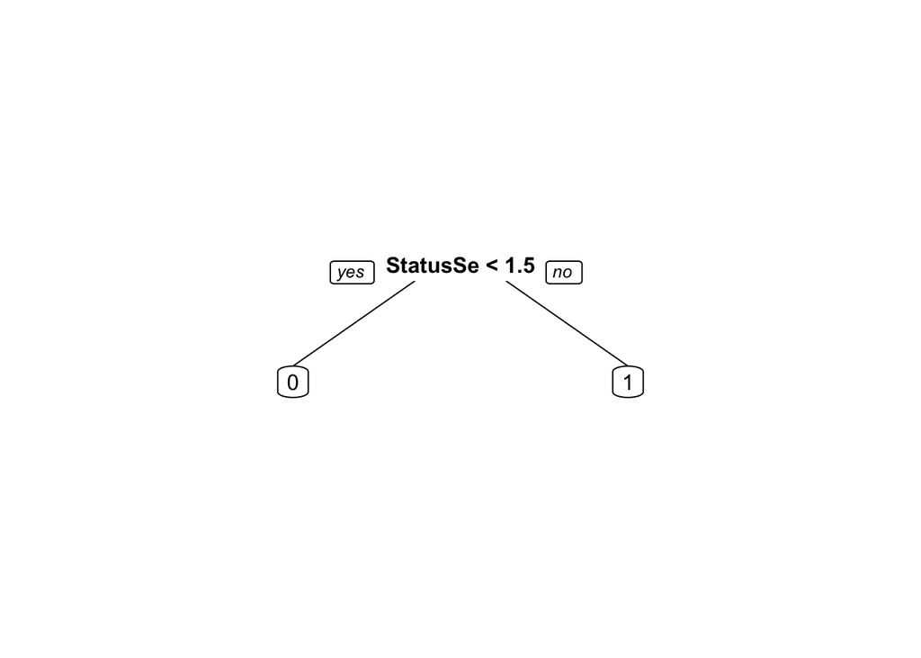

```r
# Build classification tree model with all variables
dccTree = rpart(DefaultOct05 ~ LimitAmtBin + Gender1 + Education1 + Marriage1 + AgeBin + StatusSep05 +
                  StatusAug05 + StatusJul05 + StatusJun05 + StatusMay05 + StatusApr05 +
                  PayAmtSep05 + PayAmtAug05 + PayAmtJul05 + PayAmtJun05 + PayAmtMay05 +
                  PayAmtApr05 + BalSep05 + BalAug05 + BalJul05 + BalJun05 + BalMay05 + BalApr05,
                data = dccTrain, method = "class", control = rpart.control(minbucket = 25))

# Look at tree
prp(dccTree)
```

The tree shows the payment status for September variable as its only node. If a loan is less than 1.5 months behind, then it is less likely to default. If a loan is more than 1.5 months behind its more likely to default.

Only one node appears in the tree which may be confusing since our model includes all 23 independent variables. This tells us that the September payment status is the most important factor in predicting default. Other variables are not as important.

An important note is that the September payment status variable precedes our dependent variable by one month. This may give extra weight to September in the model. In practice, a financial institution would not be limited to the previous six months of data, and there may not be an ending date for every loan since credit card debt is revolving.

Finally, we apply the model to our test set.

```r
# Apply on test set and look at accuracy of model
PredictCARTdcc = predict(dccTree, newdata = dccTest, type = "class")
table(dccTest$DefaultOct05, PredictCARTdcc)
```

```
##    PredictCARTdcc
##        0    1
##   0 5615  226
##   1 1113  546
```

The confusion matrix shows the accuracy of our model.

```r
# Examine accuracy
CAccuracy = (5615 + 546)/(5615 + 546 + 1113 + 226)
CAccuracy
```

```
## [1] 0.8214667
```

The classification tree has an accuracy of 82.15%, which is a slight improvement over the logistic regression model

### Random Forest

Our final approach is the random forest model. This was designed to improve the accuracy of CART by building a large number of CART trees. Random forest selects data randomly with replacement.

As with the previous models, we use the same split for the training and testing data sets. We then try the model on the testing data set.

```r
# Split data, build model, apply to test set
set.seed(64)
split = sample.split(dcc$DefaultOct05, SplitRatio = 0.75)
dccTrain = subset(dcc, split == TRUE)
dccTest = subset(dcc, split == FALSE)

dccTrain$Default1Oct05 = as.factor(dccTrain$Default1Oct05)
dccTest$Default1Oct05 = as.factor(dccTest$Default1Oct05)

dccForest = randomForest(Default1Oct05 ~ LimitAmtBin + Gender + Education + AgeBin + StatusSep05 +
                           StatusAug05 + StatusJul05 + StatusJun05 + StatusMay05 + StatusApr05 +
                           PayAmtSep05 + PayAmtAug05 + PayAmtJul05 + PayAmtJun05 + PayAmtMay05 +
                           PayAmtApr05 +BalSep05 + BalAug05 + BalJul05 + BalJun05 + BalMay05 +
                           BalApr05, data = dccTrain, nodesize = 25, ntree = 200)

PredictdccForest = predict(dccForest, newdata = dccTest)
table(dccTest$DefaultOct05, PredictdccForest)
```

```
##    PredictdccForest
##     NDef  Def
##   0 5540  301
##   1 1064  595
```

```r
# Examine accuracy
RAccuracy = (5540 + 595)/(5540 + 595 + 1064 + 301)
RAccuracy
```

```
## [1] 0.818
```

The accuracy of the random forrest model is 81.8%.